| FAO GLOBAL INFORMATION AND EARLY WARNING SYSTEM ON FOOD AND AGRICULTURE WORLD FOOD PROGRAMME |
| --- |

# **FAO/WFP CROP AND FOOD SUPPLY ASSESSMENT MISSION TO ARMENIA**

### **5 October 2000**

[figure not shown]

Mission Highlights

1. OVERVIEW

2. AGRICULTURE IN THE ECONOMY

- 2.1 Physical Constraints
- 2.2 Financial
- 2.3 Institutional
- 2.4 Marketing

3. FOOD PRODUCTION

- 3.1 Weather Conditions in 1999/2000 Agricultural Season
- 3.2 Grain Production, 1999/2000
- 3.3 Potato and Vegetable Production
- 3.4 Fruits
- 3.5 Livestock Production
- 3.6 Emergency Support Measures to Agricultural Sector

4. FOOD SUPPLY SITUATION

- 4.1 Food Prices and Access to Food
- 4.2 Cereal Supply/Demand Balance

5. FOOD ASSISTANCE REQUIREMENTS

- 5.1 Role of Food Aid
- 5.2 Household Coping Mechanisms
- 5.3 Estimated Caseload and Emergency Food Aid Requirements Nov. 2000 - July 2001
- 5.4 Food Aid Logistics

[figure not shown]

# **Mission Highlights**

- A severe drought has decimated crops and affected livestock production in Armenia.
- Rainfall in important agricultural areas was up to 70 percent below normal in crucial months. The drought has exacerbated problems associated with the crumbling irrigation infrastructure.
- Aggregate 2000 wheat and barley output, estimated at 205 000 tonnes, is down by 27 percent compared to 1999, while potato production fell by nearly 40 percent to 250 000 tonnes.
- Wheat and barley import requirements for 2000/01 (July/June) are estimated at 458 000 tonnes and 44 000 tonnes respectively.
- Some 145 000 tonnes of cereal food aid are needed in 2000/01, of which 70 000 tonnes are already in the pipeline, leaving a shortfall of 75 000 tonnes.
- Of particular concern are some 300 000 people who face severe food access problems and the situation is likely to worsen as the 2000/01 marketing year progresses.
- Emergency support to crop and livestock production is urgently needed to revive production capacity in the winter and spring seasons.

[figure not shown]

# **1. OVERVIEW**

Amidst reports of severe damage to agriculture in most parts Armenia due to drought, an FAO/WFP Crop and Food Supply Assessment Mission was fielded to the country from 28 August to 6 September 2000 to evaluate food production in 2000, assess the overall food supply situation, estimate cereal import requirements, including food aid, in the marketing year 2000/2001 and to identify emergency support and remedial measures needed for the agricultural sector. An earlier FAO/WFP Crop and Food Supply Assessment Mission in May 2000, before the onset of the drought, had provided preliminary estimates of the cereal supply/demand outlook in the country for the current marketing year.  
The latest mission visited many districts, including the worst affected areas, in five out of the country's 10 regions (Marzes). Extensive discussions were held with Government officials at central, regional and district levels; private farmers; personnel of UN and bilateral agencies and NGOs. Data and field information from all provinces were made available by staff of UNDP's "Integrated Support to Sustainable Human Development" project whose overall support to the Mission was invaluable.

Since June 2000, following generally normal growing conditions until May, hot and dry conditions have affected crop production. Both winter and spring rainfed cereal crops, harvested from July, were drastically reduced, particularly in the northern regions of Tavush, Lori, Shirak and Gegharkunik. The potato crop, harvested from September, was also severely affected. The problem of low water levels in rivers and canals due to the drought was compounded by the poor condition of the irrigation systems. Lack of quality seeds and agricultural know-how were other important constraining factors.

As a result, the final estimate of cereal production (including minor cereals) in 2000 has been revised down to around 216 000 tonnes from 300 000 tonnes estimated by the FAO/WFP mission in May, mainly due to reduced yields. Wheat production is estimated at about 151 000 tonnes, some 30 percent below last year's crop and about 21 percent below the previous five years' average. Potato production, a major staple crop particularly in rural areas, is estimated at 250 000 tonnes, nearly 40 percent below last year's crop.

The mission found that food prices were relatively stable in most urban markets, reflecting mainly the availability of imported food. However, access to food by the mainly subsistence rural households has become exceedingly difficult as they lost most of their produce and have little to sell or barter. After a decade of high levels of unemployment, low wages, and depletion of savings, living conditions are already precarious for most of the population, particularly in rural areas. With the added effects of the current drought, a large number of the rural population is expected to face serious food shortages in the current marketing year.

The total wheat and barley import requirement in the 2000/01 marketing year (July/June) is currently estimated at 502 000 tonnes, including 33 000 tonnes wheat equivalent of the potato deficit. With a projected commercial import of about 357 000 tonnes and a pledged food aid of 70 000 tonnes, the uncovered wheat and barley deficit amounts to 75 000 tonnes, comprising 38 000 tonnes of wheat and 37 000 tonnes of barley. Given the country's economic difficulties, a shortfall of this magnitude, if not addressed by the international community, could severely affect vulnerable groups. The effect of the drought will have less impact on food supply situation in urban areas due to the comparatively better economic conditions than in rural areas and greater access to imports. On the contrary, about one-third of the population living in rural areas, mainly subsistence farmers, will be affected resulting in complete loss of income, indebtedness and destitution as small farmers sell off their assets and livestock, as they already started doing.

The population most affected by the drought will be around 297 000 subsistence farmers in the northern part of the country - Shirak, Lori, Tavush, Geharkunik, Aragatzotn and Kotayk Marzes. With few resources left and coping mechanisms stretched to the limit, these farmers are unable to withstand the effects of the drought and the loss of harvest, particularly in the coming winter season. Consumption of seed grains and slaughtering of livestock, which has already started, will affect their productive capacity and ability to sustain themselves in the coming agricultural seasons. A timely and targeted intervention is essential to prevent widespread starvation and misery.

To revive production in the coming winter and spring, emergency support to the agricultural sector should include: support in redistribution of the little available winter wheat seed from some surplus districts as time is too tight to have imported seed for the planting season; probably distribution of appropriate seeds of wheat, barley and possibly potatoes, for the spring planting season; animal feed as stocks need to be boosted and made accessible to farmers; and rehabilitation of the crumbling irrigation systems.

[figure not shown]

# **2. AGRICULTURE IN THE ECONOMY**

Agriculture contributes about one-third to GDP and accounts for 42 percent of employment. Crop production, which is vulnerable to weather conditions (precipitation and hail) and experiences considerable annual variation, accounts for roughly 60 percent of agricultural output and livestock production about 40 percent.

Land privatization was initiated in 1991 and was the single most important factor contributing to household food security during 1991-1995. Rural households cultivate or use most of the available land resource through a combination of private ownership and leasing of state lands. Some 320 000 farmers have been allocated small farms - with scattered parcels of land - averaging between 1.4 - 1.7 hectares of arable land. In practice, given emigration and the ability to lease land from the state reserve, some farmers are farming considerably larger plots. Unofficial land consolidation has occurred but leased land is primarily used for pasture. Land may be legally sold, mortgaged, leased and subleased but officially registered land transactions are few. The land market is severely constrained by the high cadastral value of land - well above current market prices - fixed by the government, and the need to pay a substantial tax in cash based on the cadastral value when registering transactions.

Farmers are free to determine which crops to sow and where to sell them. However, their options are limited by numerous physical, financial, institutional and above all marketing constraints but the need to ensure household survival has made farmers resourceful and far from being only subsistence farmers. Agricultural production, and cereal production in particular, is likely to be influenced by the following factors for some time:

## **2.1 Physical Constraints**

Arable land is limited. The country is mountainous, with only 28 percent of land below 1500 metres altitude. Topography and climatic conditions, soil fertility and the access to irrigation water vary greatly and affect yields. With only 20 percent of the land suitable for cropping (other than pasture), small holdings and about 60 percent of the cropped land sown to cereals, crop rotation schedules are not being respected, even in the fertile valleys. Large number of farmers cultivate land which is on steep slopes and highly eroded and may have been suited for animal grazing and/or forestry. Much of the cropped land is poorly cultivated inhibiting crop growth and harvesting. With inadequate use of fertilizer over a decade, lack of adequate drainage in the valleys (30 000 hectares are saline), soil erosion (many trees were felled in 1993-1994 for fuel to cope with energy shortages), degradation of pastures, and pollution, yield potential is undermined.

Rainfall in the crucial period May-August is inadequate and irrigation is necessary to ensure satisfactory crop development. Water charges are still partially subsidized by the government. Need for investment in the establishment, reconstruction and the development of a sustainable irrigation system, including water user organizations to ensure cost recovery, is considerable.

## **2.2 Financial**

The bulk of agricultural land has been privatized but there is little support for small holdings. Farmers, like the rest of the population, have been impoverished by hyperinflation in the early nineties and limited earning opportunities. Access to formal credit for many small farmers remains difficult, not because credit is unavailable but because both collateral and sustainable disbursement opportunities are limited<sup>1</sup>. As a result, access to quality inputs and machinery is difficult.

## **2.3 Institutional**

Institutional shortcomings exacerbate the above constraints. The government has drawn up a strategy for the development of an enabling environment for agriculture, and passed a large number of laws but in recent years progress in key areas has stagnated due to political turmoil and inaction.

Lack of basic farming knowledge and management skills is a major bottleneck. The use of fertilizers, improved seeds and pesticides is limited and are usually acquired by barter. Agricultural research and the limited extension services have not been functioning properly for many years. For instance, the Agricultural Research Institute suffered significant financial cuts since 1991 and has managed to produce only four varieties of wheat in the last 20 years. Lack of major plant breeding and seed production in the country is a serious drawback. The economic cost of organizing local breeding and early generation seed production would be cheaper than importing seed. Some NGOs are setting up Seed Associations and helping with agricultural extension services. UNDP has a cost-effective model dairy, poultry and seed multiplication farms near Spitak in Lori Region. The World Bank is planning to enhance an Extension Service started by the USDA in the early 1990s but which is still a very nascent service.

## **2.4 Marketing**

Marketing constraints are possibly the chief obstacle to increasing farm income and the most difficult for farmers to overcome. The geopolitical constraints, (pending resolution of the issue of Nagorno Karabakh) and the uncertain timing of arrival and of transshipment of goods at Poti, make export of fresh produce virtually impossible, except by air, and that of processed products expensive. Despite progress in re-establishing some agro-processing capacity in the last few years<sup>2</sup>, a large number of food and agro-processing enterprises (including some large wheat mills) are not working or are working at very low capacity, reducing the competitiveness of output. The bulk of the population has very limited purchasing power and auto-consumption and barter probably account for up to two thirds of consumption of all domestic produce. Appropriate marketing and transport infrastructure for small farmers is lacking. Roads are poor and transport is expensive. As a result, there are seasonal surpluses of perishable produce (e.g. of potatoes) while shortages persist elsewhere. The barter rate of potatoes for wheat ranges from 1:1 to 3:1. Moreover, there is no market information system, with the result that many farmers in an area tend to produce the same crops if they were previously profitable, causing a glut.

However, farmers are resourceful. Although marketing of surplus produce over household consumption is both difficult and expensive, a World Bank survey carried out in 1998 found that 80 percent of farmers reported some sales of produce. On average farms marketed roughly three quarters of beef, pork and melon production, between 60-70 percent of other fruit, grape, and vegetable production, roughly one third of potato output and one fifth of grain and milk production.<sup>3</sup> Food processing in 1998 represented only 16.5 percent of industrial output but this has increased subsequently.

The rate of recovery from the shocks of the transition differs between farms, depending on their natural endowment, proximity to solvent markets and management. In mountainous/ remote/insecure areas, the limited crop/market choice and the need to ensure household food security often keeps farmers in low-input low-output scenario. Thus in Syunik marz, some farmers are obtaining wheat yields of 750 kg/ha using 250-300 kg of seed per hectare. In the colder mountainous regions, the production choices are limited to rainfed wheat/potato/hardy vegetables and livestock/fodder crop farming. Wheat production, even if yields are low and uncertain, is important to ensure household food security in an environment where cash is in short supply. In the more fertile valleys, provided the irrigation system is operational, farmers have a wider choice. Once household food supplies are ensured, their choice is determined largely by the expectation of markets for their crops. In view of existing market conditions, cereal production guarantees a low level of income per hectare, and cereals are relatively easy to produce and store. Nevertheless, there are indications that the trend of wheat displacing more intensive fruit/vegetable farming is being halted if not reversed. New vineyards are now being established and the area sown to tobacco is increasing, in the wake of foreign investment in these industries.

[figure not shown]

# **3. FOOD PRODUCTION**

The quantitative implications of the above factors for the areas planted, yield and production of food crops are difficult to assess with precision. One of the major problems of reviewing developments in agricultural and food production is the absence of data reflecting the complex nature of the ongoing developments. Budget constraints mean that there are inadequate funds and institutional support for data collection. Official data is currently based on the reports of farming organizations and a survey of 7 000 small farmers but actual yields are not measured. Some data could be misleading on account of the overlapping of the private/state economy. For example, while 100 000 hectares of agricultural land are officially reported to be unused, this may not all be lying idle and is quite likely sub-leased for use as pasture. Although official statistics may not reflect actual developments, there is no alternative source on which to base national estimates.

As can be seen in the table below, official data indicate that the aggregate area sown to crops fell steadily until 1998. The bulk of the decline was in fodder and cash crops requiring processing, notably fruit and grapes. The aggregate area sown to cereals increased steadily until 1997, reflecting an increase in the area sown to wheat. This increase was probably sharper than shown by official data as uprooting of vineyards and fruit trees was illegal in the early nineties but nevertheless occurred. On farm, there are indications of a reversal in these trends, now that there is a nascent market for quality grapes and tobacco and, increasingly, for domestic livestock products. Import competition for wheat since privatization of the import/distribution chain also plays a part in years of low international or regional wheat prices, but only a small percentage (40 000 to 45 000 tonnes) of the domestic wheat crop is officially reported to be marketed to the larger mills. The area sown to fodder crops is again increasing (and could be higher than indicated by the statistics) reflecting land leasing operations and good demand for domestic livestock products.

### **Table 1: Armenia - Trends in Agricultural Production (Area `000 hectares - Production (`000 tonnes)**

|  | **1991** | **1996** | **1997** | **1998** | **1999** | **2000/01** |
| --- | --- | --- | --- | --- | --- | --- |
| **Total area sown** | 417 | 347 | 335 | 324 | 328 | 371 |
| **Fodder crops area** | 213 | 105 | 80 | 69 | 94 | 105 |
| **TOTAL GRAINS <sup>1/</sup>** |  |  |  |  |  |  |
| Area | 153 | 184 | 199 | 199 | 176 | 184 |
| Yield (kg/ha) | 1 954 | 1 734 | 1 296 | 1 638 | 1 710 | 1 174 |
| Production | 299 | 319 | 258 | 326 | 301 | 216<sup>1/</sup> |
| **WHEAT** |  |  |  |  |  |  |
| Area | 80 | 93 | 113 | 124 | 112 | 104 |
| Yield (kg/ha) | 2 138 | 2 108 | 1 584 | 1 927 | 1 911 | 1 452 |
| Production | 171 | 196 | 179 | 239 | 214 | 151 |
| **BARLEY** |  |  |  |  |  |  |
| Area | 65 | 77 | 74 | 64 | 51 | 78 |
| Yield (kg/ha) | 1 785 | 1 325 | 797 | 1 109 | 1 275 | 692 |
| Production | 116 | 102 | 59 | 71 | 65 | 56 |
| **POTATOES** |  |  |  |  |  |  |
| Area | 23 | 33 | 33 | 33 | 32 | 35 |
| Yield (kg/ha) | 11 957 | 12 818 | 10 909 | 13 333 | 12 938 | 7 143 |
| Production | 275 | 423 | 360 | 440 | 414 | 250 |
| **VEGETABLES** |  |  |  |  |  |  |
| Area | 22 | 21 | 20 | 19 | 21 | 20 |
| Yield (kg/ha) | 20 136 | 21 190 | 18 450 | 20 789 | 21 381 | 19 000 |
| Production | 443 | 445 | 369 | 395 | 449 | 380 |
| **FRUIT** |  |  |  |  |  |  |
| Area | 46 | 34 | 25 | 21 | 22 | 21 |
| Yield (kg/ha) | 4 717 | 4 770 | 4 378 | 6 050 | 4 000 | 6 190 |
| Production | 217 | 158 | 109 | 126 | 88 | 130 |
| **GRAPES** |  |  |  |  |  |  |
| Area | 27 | 21.8 | 17.8 | 15.7 | 15.7 | 15.2 |
| Yield (kg/ha) | 7 815 | 7 310 | 6 067 | 6 752 | 7 325 | 7 480 |
| Production | 211 | 158 | 108 | 106 | 115 | 113 |
| **LIVESTOCK PRODUCTION** |  |  |  |  |  |  |
| Meat (liveweight '000 tonnes) | 133 | 83 | 84 | 86 | 86 | 160 |
| Milk ('000 litres) | 412 | 431 | 435 | 457 | 466 | 240 |
| Eggs (millions) | 482 | 192 | 191 | 219 | 326 | 350 |

> > Source: Ministry of Agriculture and National Statistics Office of Armenia.

> > 1/ Includes minor cereals such as oats, maize and mixed grains.

## **3.1 Weather Conditions in 1999/2000 Agricultural Season**

The summer months of 2000 were unusually dry and hot over almost all parts of Armenia. Rains were overall lower than the long-term average, however, as depicted in Figures 1-4, extremely poor rainfall was recorded in June, July and August. With the exception of May, reduced average monthly precipitation was recorded in most weather stations. Total rainfall in these months was nearly 70 percent below average in most cases. Furthermore, temperatures rose to unprecedented levels, up to 5 degrees centigrade higher than normal, accelerating the level of evapo-transpiration and causing deep ruptures in the soil. The level of humidity in the air was less than 30 percent of normal.

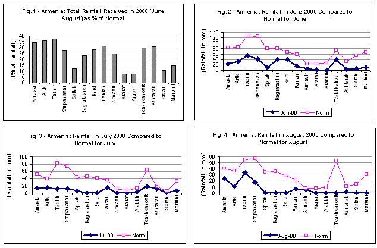

The country's irrigation systems are largely surface-water based. Ground water is also used in some areas. Snow cover is the main source of source water feeding into the country's river systems. Poor rains and snow cover in 2000 prompted a sharp decline in levels of water in rivers and canals that limited irrigation activities.

## **3.2 Grain Production, 1999/2000**

In August 2000, the Government officially reported the state of the drought and the estimated damage on agricultural production. Following one of the driest summer months for decades, water levels in most rivers and Lake Sevan were drastically reduced. In addition, the extensive use of ground water for irrigation purposes has significantly lowered the water table in most areas. The state of disrepair of irrigation infrastructure and consequent loss of limited water has also exacerbated the problem.<sup>4</sup> Water users associations do not function properly and many farmers simply do not have the cash to pay and so get cut off or left out of the water rota.

As a result, yields of rainfed crops have been drastically reduced, with vast areas of cultivated but non-productive land left un-harvested, particularly in the northern regions. Irrigated potato crops have also been severely reduced, reversing the growth noted over the past few years. By the same token, livestock production has been severely affected with drastically reduced barley and hay production.

### **Table 2 : Armenia - Grain Production by Region, 2000**

| **Region (Marz)** | Area harvested (ha) | Production (`000 tonnes) | **Yield** **(tonnes/ha)** |
| --- | --- | --- | --- |
| Aragatzoten Ararat Armavir Gegharkunik Lori Kotayk Shirak Syunik Vayots Dzor Tavush Yerevan | 20 751 13 695 20 096 37 411 11 160 14 684 39 260 15 921 3 517 6 847 353 | 15 112 38 625 50 010 9 000 14 290 16 605 53 800 10 050 2 125 5 245 923 | 0.73 2.82 2.49 0.24 1.28 1.13 1.37 0.63 0.60 0.77 2.61 |
| **TOTAL** | **183 695** | **215 785** | **1.17** |

> > Source: Ministry of Agriculture

## **3.3 Potato and Vegetable Production**

Potato is one of the major staple crops in Armenia. Area under potatoes has steadied between 31-34 thousand hectares since 1993 and accounts for about 10 percent of the total annual sown area. Potato yields vary considerable between regions depicting the degree of access to water resources. In the mainly irrigated fields of the Ararat valley, typical yield in a normal year averages between 15 to 20 tonnes/ha while in the major growing regions of Lori and Gerharkunik the average is about 10 tonnes/ha.<sup>5</sup> This year, field visits have indicated that the potato crop, for harvest from September, is in a rather poor state. Therefore, despite higher official forecast, the Mission forecast for the potato crop is a reduced 250 000 tonnes, some 40 percent below last year.

Area under vegetables, estimated at about 20 000 ha, is about 5 percent of total sown area. As in the case of the potato crop, the projected output of vegetables is down compared to last year, but by a lesser rate of about 15 percent.

## **3.4 Fruits**

Apple, apricot and peaches are some of the main fruits grown. Lack of essential facilities and infrastructure have limited the effective marketing of fruits. Fruit production was spared from this year's severe drought, mainly due to its heavy reliance on irrigation. Thus fruit production, estimated at 130 000 tonnes, is about 48 percent above last year's production. The mission was informed by individual farmers and officials in villages that current prices of these fruits are so low that they are not even picking them.

## **3.5 Livestock Production**

In 1999, the livestock population consisted of nearly 479 000 head of cattle (of which 262 000 were cows), 549 000 sheep and goats, 71 000 pigs and some 2.9 million poultry. Minor variations of about 10 percent were recorded in the livestock population since 1991.Virtually every rural family has at least one cow. In the single cow mixed income families the livestock products often represent about 40 percent of the household income. There are no fully pastoral communities in the country with the exception of some Kurdish villages in some mountainous areas. There are limited model farms assisted by international organizations, which exhibit higher levels livestock products such as milk, cheese and meat. Natural pasture of variable quality represents the main feed for animals in the summer and hay and/or straw over winter. Scarcity of feed is the main factor affecting production. Winter food reserves are essential and must last a minimum of five to six months. Over winter some barley and/or wheat are fed but no concentrates.

During normal seasons some 86 000 tonnes of meat and about 460 000 liters of milk are produced. During 2000/01 it is anticipated that milk production may fall by up to 50 percent from the projected 480 000 liters. Meat production is expected to rise to about 160 000 tonnes because of serious de-stocking. Some sources suggest that the country's overstocking has increased the extent of rangeland degradation, particularly in the low rainfall areas which represent most of the natural grazing areas.

## **3.6 Emergency Support Measures to Agricultural Sector**

From the above the following emergency measures warrant serious consideration:

- As carryover seed stocks will be negligible, appropriate seeds of wheat, barley and potatoes are likely to be needed for the spring planting season.
- Animal feed stocks need to be boosted and made accessible to farmers in anticipation of low straw and/or no range grazing likely to be available until next spring.
- Rehabilitation of the crumbling irrigation systems, including deep wells to improve agricultural production.
- Introduction of new credit schemes to assist farmers to purchase inputs including livestock feeds, seeds and agro-chemicals.

Details of input requirements, associated costs and other measures will be issued in a separate report by FAO's Special Relief Operations Service.

[figure not shown]

# **4. FOOD SUPPLY SITUATION**

## **4.1 Food Prices and Access to Food**

Food prices were relatively stable in most markets, reflecting mainly the availability of imported food. However, access to food for the mainly subsistence rural households has become exceedingly difficult as they lost most of their produce and have little to sell or barter. Grain prices have also started increasing in some markets in northern parts of the country where crop failures were more significant. After a decade of high levels of unemployment, low wages, and the steady erosion of safeguards against poverty, living conditions are already precarious for most of the population, particularly in rural areas. With the added effects of the current drought, a large number of the rural population is expected to face serious food shortages in the current marketing year.

## **4.2 Cereal Supply/Demand Balance**

### **Table 3: Armenia - Staple Food Supply/Demand Balance for 2000/01 (`000 tonnes)**

|  | Wheat | Barley | Potatoes |
| --- | --- | --- | --- |
| **Domestic availability** | **151** | **54** | **250** |
| Stock draw-down | --- | --- | --- |
| Domestic production | 151 | 54 | 250 |
| **Total utilization** | **576** | **98** | **394** |
| Food Use Feed Seed | 425 104 24 | 10 60 20 | 183 50 123 |
| Other uses/losses | 23 | 8 | 38 |
| Stock build-up | --- | --- | --- |
| **Import requirements** | **425** | **44** | **144** |
| (Cereal equivalent) | 425 | 44 | 33* |
| Anticipated Commercial | 350 | 7 | 1 |
| Food aid pledges | 70 | --- | --- |
| **Uncovered deficit** | **38** | **37** |  |

> > > > * Wheat grain equivalent.

[figure not shown]

# **5. FOOD ASSISTANCE REQUIREMENTS**

## **5.1 Role of Food Aid**

Armenia is confronted with the drought plaguing Central and South Asia, the Middle East as well as the Caucasus. The drought, whose effects became apparent in June-July 2000, mostly affected the mountainous rain-fed areas in the north of the country. Crop production is down 27 percent for wheat and barley and 40 percent for the potato production, as compared to the 1999 harvest.

The negative effects of the drought greatly exacerbate pre-existing structural agricultural problems and extensive vulnerability among the poorest segments of the population. Even under normal circumstances poor subsistence farmers can barely produce enough for their own household food consumption. Armenia is a highly food insecure country with 28 percent of the population undernourished.

Since autumn of 1999, Armenia has suffered a period of increased political uncertainty and an economic downturn, which has resulted in a crisis in state budgets. Because of this instability in the first five months of 2000, GDP grew by just 0.3 percent against 4.6 percent in the first quarter of 1999. In particular, the pace of growth in the agricultural sector, as well as in trade and construction, decreased significantly.

Large-scale under- and unemployment has been experienced in recent years and is based on several factors: a) the difficulties associated with macro-economic reforms, b) the long-time unsettled dispute over Nagorno-Karabagh, c) the aftermath of the disastrous earthquake in 1988, which destroyed 40 percent of the economy, d) and the regional financial crisis.

The Government is currently working on a poverty reduction strategy. Though the intentions seem ambitious, they clearly reflect the need to counter high unemployment, high migration rates, corruption and increasing poverty. But with the current drought situation, tax revenues are likely to decrease, further undermining the government's ability to provide for its most needy and vulnerable citizens through its social welfare programme**.**

WFP has implemented emergency food aid operations in Armenia since late 1993. Initially focusing on refugees and internally displaced people, WFP soon started addressing the needs of the resident vulnerable groups who were exposed to almost as much hardship as the refugees. Over the past seven years, WFP has distributed 62 000 tonnes of food worth approximately 42 million dollars, assisting more than 1.5 Million people.

The WFP Country Office implements a two-tier approach in food provision: 1) relief distribution of supplementary rations for the socially vulnerable, including refugees; and 2) Multi-purpose Food for Work (FFW) for able-bodied unemployed people. Under relief distribution, WFP implements a Winter Food Preservation Project reaching15,000 women heads of households and single women in economically depressed areas.

The overall objective of WFP interventions in Armenia is to enhance household food security for a large number of beneficiaries in the short to medium term. WFP also seeks to create communal assets, which could further improve food production, health and living conditions through the rehabilitation of social infrastructure (drinking water and sewerage systems, housing and public buildings repair and construction.

## **5.2 Household Coping Mechanisms**

Agriculture accounts for 42 percent of employment opportunities in Armenia and contributes one-third of the GDP. Although most of the land has been privatized into small holdings since the breakup of the Soviet Union in 1991, the new and often very small farmers receive little or no institutional backup and extension services. As a result of the chronic shortage of quality seeds, the deterioration of the irrigation system and the lack of capital the average yield of grain and most other crops remains low. The 1998-1999 drought has further reduced the national crop production and undermined other agricultural production in 1999.

Armenia suffers from widespread poverty. According to the Government-devised vulnerability index PAROS, 30 percent of households have no coping mechanism and are considered extremely poor. Many households rely on assistance from relatives and occasional jobs. Inadequate employment opportunities have led to seasonal or total emigration from the country, especially among able-bodied men in search of work and income. As a result, Armenia has one of the highest migration rates in the world. The majority of immigrants move to Russia. But due to the recent economic crises in Russia, migration workers have limited opportunities to earn enough money to send back to their families in Armenia. More single-parent households (mostly female-headed) may emerge as a result of out-migration by men and family fathers, in search for work after this drought. This situation will place an additional burden on women who will then not only have to cope with the existing food scarcity, but also with the increase in family responsibility, as sole caretakers of the children and the elderly.

Other coping mechanisms are sale of assets, humanitarian aid, and social solidarity. In rural Armenia borrowing from neighbours and the better-off is a common practice. Not being able to make ends meet, subsistence farmers often have to start borrowing food items as early as February, even in normal years. Debts are "repaid" with the new crop starting in July. This year with the "better-off" farmers themselves suffering from crop losses, even this coping mechanism will be largely unavailable. Due to earlier disasters like the 1998-99 drought, many families have already sold whatever jewellery, or other valuable possessions they had.

The overall socio-economic and agricultural situation is alarming with the large shortfall in cereal and in potato production, the fragile nutritional status of many people and the limited purchasing power and capacity to cope for most, particularly female-headed households. Due to economic hardship, the diet of the vulnerable population has been mainly bread, potatoes and cabbages. Now with the drought even these food items which by themselves do not constitute an adequate diet will not be readily available to the drought affected households.

The nutritional status of the vulnerable population could be further exacerbated by Armenia's usually harsh winter. A 1998 nutrition survey by UNICEF found that 15 percent of women in the age-group of 15-45 years were mildly to moderately anemic. It is now estimated that 50-60 percent of pregnant women are anemic in some regions of the country, according to a recent study by the Ministry of Health. In 1999, 121 women out of 1000 had complications during delivery due to anemia. (In comparison, the figure in 1985 was 9.5 and in 1990 13.8 out of 1000.) With the decline in food availability at the household level and the harsh winter, the nutritional status of pregnant women is in danger of declining further.

Subsistence farmers in the drought affected north of the country have few resources or coping mechanisms left to juggle the negative effects of this drought. In the coming months, as early as November, in many places their limited harvest will be depleted, leaving them in a seriously food insecure situation. The available coping mechanisms such as emigration or the consumption of seeds and livestock may easily add to the adverse consequences of the drought in future years.

## **5.3 Estimated Caseload and Emergency Food Aid Requirements Nov. 2000 - July 2001**

While the drought has affected the whole agricultural sector of Armenia, its devastating impact has been mostly evident in the rainfed areas in the northern part of the country. Although it has affected most rural households, the better off farmers still have some coping mechanism to cushion the effects of this drought. On the other hand, subsistence farmers, accounting for as much as 90 percent of the farmers in the drought-affected areas, are already living on the bare minimum and are in danger of starvation. It is this segment of the population, which is most vulnerable, and will need food aid assistance from November 2000 until July 2001.

Tens of thousands of vulnerable people (such as single elderly pensioners and the disabled), whose livelihoods are based on the subsistence farmers' social and economic conditions, will also suffer. These vulnerable groups depend on the availability of cheap food in local markets, not to mention the strong social solidarity tradition in northern Armenia, which helped many of these people survive the harsh economic transition. The capacity of subsistence farmers to maintain this tradition is threatened by the drought.

### **Table 4 : Armenia - Number of People Critically in Need of Food Assistance and the Amount of Wheat required as Food Assistance from November 2000 to June 2001**

[output not shown]

> * These figures are based on available information received from each province (a) on the general impact of the drought on farming, (b) on the social impact on subsistence farmers including their potential capacity to cope with the situation, taking into account land and cattle ownership, (c) as well as affected non-subsistence farmers.

## **5.4 Food Aid Logistics**

WFP logistics arrangements can follow the same course as the on-going programme. WFP food arriving from Europe and the United States can be shipped to the Georgian Black Sea port of Poti for onward rail passage to the WFP extended delivery points (EDPs) in Armenia, both in Vanadzor and in Yerevan.

However, the additional tonnage planned for the EMOP will require an expanded logistics network. The current total storage and handling capacity is around 20 000 tonnes under the PRRO. To accommodate an increased tonnage, additional warehouse and transport capacity, as well as more staff would be needed. Additional trucking capacities would also have to be identified.

[output not shown]

[**Back to menu**](https://www.fao.org/WAICENT/faoinfo/economic/giews/english/alertes/sptoc.htm)

1 The availability of credit for the agrarian sector has increased sharply in recent years, (from 2 billion drams in 1996 to 20 billion drams in 1999, including nearly 3 billion-dram credit allocations for the irrigation system and nearly 12 million drams made available by international programmes). (500-540 drams = US$1).

2 Notably in dairy and poultry production, fruit and vegetable processing (fruit juices, jams, tomato paste) and viticulture (brandy and wine).

3 Armenia's Private Agriculture. 1998 Survey of Family Farms, World Bank.

4 The World Bank initiated a USD 50 million project rehabilitating irrigation head works in some areas in 1999 but the maintenance at the secondary and tertiary canals is poor.

5 Compare these figures to potato yields between 40 to 50 tonnes/ha in some European countries.

6 Based on the survey carried out in 1996/1997 "Republic of Armenia: Social Snapshot and Poverty".

7 Livestock production is based mainly on pasture and fodder crops, straw and bran, but barley and wheat are also used. This year, however, an increase in imported feed, mainly barley, is highly recommended to compensate for the reduced availability of crop residues, pasture and fodder, to prevent large-scale de-stocking and to ensure normal milk production.

8 Field observations have indicated planting of wheat in the current winter cropping season, already underway, has been disrupted due to continued drought and lack of seeds.